# Quant Final

MC Abbott

11/23/2021

## Load Libraries

```r
library(tidyverse)
library(interactions)
```

## Load Data

```r
data_mainst <- read_csv("exam_data_mabbott.csv")
```

## Review Data

### Variables

- lost_parking: The number of parking spaces adjacent to each business that have been removed with the street redesign. These number are all positive, but they all represent a loss of parking.
- transit_dist: The distance (in miles) from each business to the nearest transit stop, after the streetcar opens for service
- bike_chng: The percent change in daily bicycle volumes adjacent to each business after the project opened. A positive value means bike volumes increased.
- type: One of 7 business types: Clothing, Furniture, Gas station, Drugstore, Books, or Restaurant (note: Some students might have a dataset that doesn’t include all seven of these)
- parking_cost_change: The percent change in parking cost at parking meters adjacent to each business. A positive value means the cost of parking increased.
- pct_sales_chng: The percent change in sales at each business after the project. A positive value means sales revenue increased.

## Question 1

Question: What was the average change in sales for Main Street businesses? Did sales increase or decrease, on average? How confident are you about that?

Approach: t-test

```r
t.test(data_mainst$pct_sales_chng)
```

```
##
##  One Sample t-test
##
## data:  data_mainst$pct_sales_chng
## t = 15.032, df = 419, p-value < 2.2e-16
## alternative hypothesis: true mean is not equal to 0
## 95 percent confidence interval:
##  0.02410834 0.03136178
## sample estimates:
##  mean of x
## 0.02773506
```

On average, Main Street businesses saw a 2.8% increase in sales. The 95-percent confidence interval for the increase is 2.4 to 3.1 percent. Since the p-value is less than 2.2e-16, we can be more than 99.9% confident in our results and that there was an actual increase in sales.

## Question 2

Question: Did the cost of parking change more for some types of businesses than for others? How confident are you about those differences?

Approach: bi-variate regression

Step 1: Determine which business type to use as the comparison.

```r
data_mainst %>%
  group_by(type) %>%
  summarise (number = n()) %>%
  mutate(percent = round(100 *number / sum(number))) %>%
  arrange(desc(number))
```

```
## # A tibble: 7 × 3
##   type        number percent
##   <chr>        <int>   <dbl>
## 1 Books          120      29
## 2 Furniture      104      25
## 3 Clothing        78      19
## 4 Restaurant      54      13
## 5 Grocery         40      10
## 6 Drugstore       16       4
## 7 Gas station      8       2
```

Step 2: Book stores (!!!) are the most common business type and so we will use it as our intercept and compare other results back to it with a process of releveling.

```r
data_mainst <- data_mainst %>%
  mutate(type = as.factor(type)) %>%
  mutate(type = relevel(type, "Books"))
```

Step 3: Conduct bivariate regression.

```r
parkingcost_bytype <- lm(parking_cost_change ~ type, data = data_mainst)

summary(parkingcost_bytype)
```

```
##
## Call:
## lm(formula = parking_cost_change ~ type, data = data_mainst)
##
## Residuals:
##      Min       1Q   Median       3Q      Max
## -0.11461 -0.03056 -0.00240  0.03258  0.10039
##
## Coefficients:
##                  Estimate Std. Error t value Pr(>|t|)
## (Intercept)      0.121958   0.003962  30.782  < 2e-16 ***
## typeClothing    -0.015343   0.006312  -2.431   0.0155 *
## typeDrugstore    0.026042   0.011551   2.254   0.0247 *
## typeFurniture   -0.084401   0.005815 -14.515  < 2e-16 ***
## typeGas station -0.116458   0.015848  -7.348 1.08e-12 ***
## typeGrocery     -0.063558   0.007924  -8.021 1.09e-14 ***
## typeRestaurant   0.032356   0.007112   4.550 7.08e-06 ***
## ---
## Signif. codes:  0 '***' 0.001 '**' 0.01 '*' 0.05 '.' 0.1 ' ' 1
##
## Residual standard error: 0.0434 on 413 degrees of freedom
## Multiple R-squared:  0.5049, Adjusted R-squared:  0.4977
## F-statistic: 70.21 on 6 and 413 DF,  p-value: < 2.2e-16
```

All of the results were statistically significant with at least 95-percent confidence. For book stores, furniture stores, gas stations, grocery stores and restaurants we are even more confident given their near-zero p-values, with a confidence of at least a 99.9-percent.

## Question 3

Question: Not counting any kind of effect of the changes to parking and cycling have had, what kind of effect did it have on businesses if the closest transit stop got closer or further away?

Approach: multivariate regression looking at change in distance in transit to the change in sales, holding change in parking supply, changes in parking price, and changes in bike traffic constant

```r
model1 <- lm(pct_sales_chng ~ transit_dist + parking_cost_change + lost_parking + bike_chng, data = data_mainst)

summary(model1)
```

```
##
## Call:
## lm(formula = pct_sales_chng ~ transit_dist + parking_cost_change +
##     lost_parking + bike_chng, data = data_mainst)
##
## Residuals:
##       Min        1Q    Median        3Q       Max
## -0.067432 -0.022772 -0.003126  0.017904  0.088180
##
## Coefficients:
##                       Estimate Std. Error t value Pr(>|t|)
## (Intercept)          0.0153292  0.0041381   3.704 0.000241 ***
## transit_dist        -0.1702945  0.0257996  -6.601 1.25e-10 ***
## parking_cost_change  0.2894604  0.0268593  10.777  < 2e-16 ***
## lost_parking        -0.0014247  0.0007803  -1.826 0.068604 .
## bike_chng            0.0723665  0.0295476   2.449 0.014732 *
## ---
## Signif. codes:  0 '***' 0.001 '**' 0.01 '*' 0.05 '.' 0.1 ' ' 1
##
## Residual standard error: 0.03055 on 415 degrees of freedom
## Multiple R-squared:  0.3534, Adjusted R-squared:  0.3472
## F-statistic: 56.71 on 4 and 415 DF,  p-value: < 2.2e-16
```

Analysis: For every one mile increase in distance from a transit stop, sales decreased by 17 percentage points, controlling for known factors including the changes in parking cost, parking supply, and bike traffic.

## Question 4

Question: Was the effect of transit on sales different for some types of businesses than for others? What was the difference, if any?

Approach: interaction effect between transit distance and business type on regression, holding all other variables constant

```r
model2 <- lm(pct_sales_chng ~ type + transit_dist + parking_cost_change + lost_parking + bike_chng + type:transit_dist, data = data_mainst)

summary(model2)
```

```
##
## Call:
## lm(formula = pct_sales_chng ~ type + transit_dist + parking_cost_change +
##     lost_parking + bike_chng + type:transit_dist, data = data_mainst)
##
## Residuals:
##       Min        1Q    Median        3Q       Max
## -0.061712 -0.010008  0.000403  0.009564  0.062620
##
## Coefficients:
##                                Estimate Std. Error t value Pr(>|t|)
## (Intercept)                   0.0804802  0.0048792  16.494  < 2e-16 ***
## typeClothing                  0.0116318  0.0056212   2.069  0.03916 *
## typeDrugstore                -0.0062316  0.0116140  -0.537  0.59187
## typeFurniture                -0.0890117  0.0056058 -15.879  < 2e-16 ***
## typeGas station              -0.0765849  0.0121305  -6.313 7.21e-10 ***
## typeGrocery                  -0.0881828  0.0065304 -13.503  < 2e-16 ***
## typeRestaurant                0.0074493  0.0062608   1.190  0.23482
## transit_dist                 -0.3069359  0.0327156  -9.382  < 2e-16 ***
## parking_cost_change          -0.0267550  0.0235766  -1.135  0.25713
## lost_parking                 -0.0013845  0.0005019  -2.759  0.00607 **
## bike_chng                     0.0496021  0.0193101   2.569  0.01057 *
## typeClothing:transit_dist    -0.1080054  0.0507275  -2.129  0.03385 *
## typeDrugstore:transit_dist    0.0357753  0.1042136   0.343  0.73156
## typeFurniture:transit_dist    0.3187029  0.0471369   6.761 4.82e-11 ***
## typeGas station:transit_dist  0.2940322  0.1370833   2.145  0.03256 *
## typeGrocery:transit_dist      0.3017583  0.0569118   5.302 1.89e-07 ***
## typeRestaurant:transit_dist  -0.0286702  0.0543849  -0.527  0.59836
## ---
## Signif. codes:  0 '***' 0.001 '**' 0.01 '*' 0.05 '.' 0.1 ' ' 1
##
## Residual standard error: 0.01962 on 403 degrees of freedom
## Multiple R-squared:  0.741,  Adjusted R-squared:  0.7307
## F-statistic: 72.07 on 16 and 403 DF,  p-value: < 2.2e-16
```

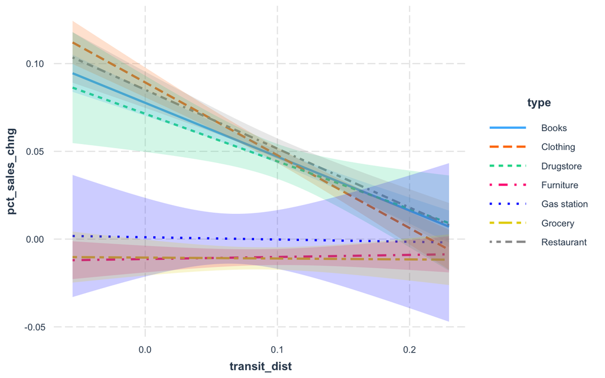

```r
interact_plot(model2, pred = transit_dist, interval = TRUE, modx = type)
```

While the results of the model were statistically significant for furniture stores, gas stations, and grocery stores, the models show that there wasn’t a substantial effect that distance to transit had on sales for these particular type of businesses. In contrast, clothing stores did experience a different effect of distance from transit on sales: clothing stores had an an additional decrease in sales by 10% for every 1-mile increase in distance to a transit stop, when compared to book stores.

For both drug stores and restaurants, the model did not produce statistically significant results.